# Project #2

## Data Wrangling (Acquisition & Cleaning).

```python
#First read in the titanic file

import pandas as pd
import numpy as np
import math
import matplotlib.pyplot as plt
import seaborn as sns
%pylab inline


pd.options.display.max_rows = 20

titanic_df = pd.read_csv('titanic_data.csv')
titanic_df.head(20)
```

|  | PassengerId | Survived | Pclass | Name | Sex | Age | SibSp | Parch | Ticket | Fare | Cabin | Embarked |
| --- | --- | --- | --- | --- | --- | --- | --- | --- | --- | --- | --- | --- |
| 0 | 1 | 0 | 3 | Braund, Mr. Owen Harris | male | 22.0 | 1 | 0 | A/5 21171 | 7.2500 | NaN | S |
| 1 | 2 | 1 | 1 | Cumings, Mrs. John Bradley (Florence Briggs Th... | female | 38.0 | 1 | 0 | PC 17599 | 71.2833 | C85 | C |
| 2 | 3 | 1 | 3 | Heikkinen, Miss. Laina | female | 26.0 | 0 | 0 | STON/O2. 3101282 | 7.9250 | NaN | S |
| 3 | 4 | 1 | 1 | Futrelle, Mrs. Jacques Heath (Lily May Peel) | female | 35.0 | 1 | 0 | 113803 | 53.1000 | C123 | S |
| 4 | 5 | 0 | 3 | Allen, Mr. William Henry | male | 35.0 | 0 | 0 | 373450 | 8.0500 | NaN | S |
| 5 | 6 | 0 | 3 | Moran, Mr. James | male | NaN | 0 | 0 | 330877 | 8.4583 | NaN | Q |
| 6 | 7 | 0 | 1 | McCarthy, Mr. Timothy J | male | 54.0 | 0 | 0 | 17463 | 51.8625 | E46 | S |
| 7 | 8 | 0 | 3 | Palsson, Master. Gosta Leonard | male | 2.0 | 3 | 1 | 349909 | 21.0750 | NaN | S |
| 8 | 9 | 1 | 3 | Johnson, Mrs. Oscar W (Elisabeth Vilhelmina Berg) | female | 27.0 | 0 | 2 | 347742 | 11.1333 | NaN | S |
| 9 | 10 | 1 | 2 | Nasser, Mrs. Nicholas (Adele Achem) | female | 14.0 | 1 | 0 | 237736 | 30.0708 | NaN | C |
| 10 | 11 | 1 | 3 | Sandstrom, Miss. Marguerite Rut | female | 4.0 | 1 | 1 | PP 9549 | 16.7000 | G6 | S |
| 11 | 12 | 1 | 1 | Bonnell, Miss. Elizabeth | female | 58.0 | 0 | 0 | 113783 | 26.5500 | C103 | S |
| 12 | 13 | 0 | 3 | Saundercock, Mr. William Henry | male | 20.0 | 0 | 0 | A/5. 2151 | 8.0500 | NaN | S |
| 13 | 14 | 0 | 3 | Andersson, Mr. Anders Johan | male | 39.0 | 1 | 5 | 347082 | 31.2750 | NaN | S |
| 14 | 15 | 0 | 3 | Vestrom, Miss. Hulda Amanda Adolfina | female | 14.0 | 0 | 0 | 350406 | 7.8542 | NaN | S |
| 15 | 16 | 1 | 2 | Hewlett, Mrs. (Mary D Kingcome) | female | 55.0 | 0 | 0 | 248706 | 16.0000 | NaN | S |
| 16 | 17 | 0 | 3 | Rice, Master. Eugene | male | 2.0 | 4 | 1 | 382652 | 29.1250 | NaN | Q |
| 17 | 18 | 1 | 2 | Williams, Mr. Charles Eugene | male | NaN | 0 | 0 | 244373 | 13.0000 | NaN | S |
| 18 | 19 | 0 | 3 | Vander Planke, Mrs. Julius (Emelia Maria Vande... | female | 31.0 | 1 | 0 | 345763 | 18.0000 | NaN | S |
| 19 | 20 | 1 | 3 | Masselmani, Mrs. Fatima | female | NaN | 0 | 0 | 2649 | 7.2250 | NaN | C |

```python
#Check to see if there are any duplicate passenger entries

titanic_df['PassengerId'].nunique()
```

```
891
```

```python
titanic_df.isnull()
```

|  | PassengerId | Survived | Pclass | Name | Sex | Age | SibSp | Parch | Ticket | Fare | Cabin | Embarked |
| --- | --- | --- | --- | --- | --- | --- | --- | --- | --- | --- | --- | --- |
| 0 | False | False | False | False | False | False | False | False | False | False | True | False |
| 1 | False | False | False | False | False | False | False | False | False | False | False | False |
| 2 | False | False | False | False | False | False | False | False | False | False | True | False |
| 3 | False | False | False | False | False | False | False | False | False | False | False | False |
| 4 | False | False | False | False | False | False | False | False | False | False | True | False |
| 5 | False | False | False | False | False | True | False | False | False | False | True | False |
| 6 | False | False | False | False | False | False | False | False | False | False | False | False |
| 7 | False | False | False | False | False | False | False | False | False | False | True | False |
| 8 | False | False | False | False | False | False | False | False | False | False | True | False |
| 9 | False | False | False | False | False | False | False | False | False | False | True | False |
| ... | ... | ... | ... | ... | ... | ... | ... | ... | ... | ... | ... | ... |
| 881 | False | False | False | False | False | False | False | False | False | False | True | False |
| 882 | False | False | False | False | False | False | False | False | False | False | True | False |
| 883 | False | False | False | False | False | False | False | False | False | False | True | False |
| 884 | False | False | False | False | False | False | False | False | False | False | True | False |
| 885 | False | False | False | False | False | False | False | False | False | False | True | False |
| 886 | False | False | False | False | False | False | False | False | False | False | True | False |
| 887 | False | False | False | False | False | False | False | False | False | False | False | False |
| 888 | False | False | False | False | False | True | False | False | False | False | True | False |
| 889 | False | False | False | False | False | False | False | False | False | False | False | False |
| 890 | False | False | False | False | False | False | False | False | False | False | True | False |

891 rows × 12 columns

```python
df = titanic_df.drop(['Cabin', 'Embarked'], axis=1)
df_new = df.dropna(how='any')
```

Something's weird though. It shows that there are 177 passengers without any age value. But the length of the df_new is 712, meaning that there were 179 passengers taken out of the data for having no age value. Why is there an additional 2 passengers taken out in df_new? After further looking at the data, I found that the 'Embarked' Column had 2 'NaNs' which also deleted an additional two passengers when I did my df.dropna function. Therefore in order to change this I added the 'Embarked' column to the code "titanic_df.drop" function.

```python
#We're trying to find the number of age values in the age column using these two methods: 'isnull()' and 'value_counts()'

df_new['Age'].isnull().value_counts()
```

```
False    714
Name: Age, dtype: int64
```

Now the new dataset is devoid of any missing values. I can now move on to the analysis portion of the data analysis portion. The reason we took out the rows missing age values, is because later when we calculate the average of ages our results will be consistent with passengers that had their age listed. Say we did not remove these missing values, when we calculate the average age, it will not be representative of the passengers in a certain category, because some passengers in that category will not have their age listed. Later on, when we're figuring out the connections between age and other variables, this inconsistency will also affect the analysis of other variables that also deal with age.

## Question.

Which factors are most important when it comes to predicting one's survival in the Titanic?

## Data Exploration.

```
Number of titanic survivors: 290
Number of titanic dead: 424
Average age aboard titanic: 29.6991176471
Number of males: 453
Number of females: 261
```

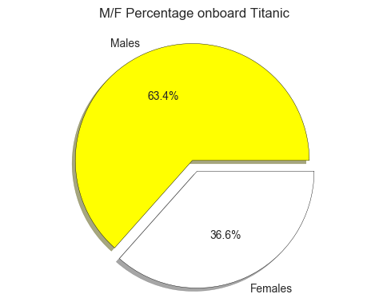

```python
#Some introductory facts

total_alive = df_new['Survived'].sum()
print("Number of titanic survivors: {}".format(total_alive))

total_dead = len(df_new) - total_alive
print("Number of titanic dead: {}".format(total_dead))

average_age = df_new['Age'].mean()
print("Average age aboard titanic: {}".format(average_age))

mf_count = df_new['Sex'].value_counts()

print("Number of males: {}".format(mf_count.iloc[0]))
print("Number of females: {}".format(mf_count.iloc[1]))

plt.pie([mf_count.iloc[0], mf_count.iloc[1]], labels=['Males', 'Females'], shadow=True, autopct='%1.1f%%', explode=[0, 0.1], colors=['yellow',
    'white'])
plt.axis('equal')
plt.title('M/F Percentage onboard Titanic', y=1.08)

#This pie chart shows the percentage of males and females aboard the titanic.
```

Perhaps there were a lot more males on the ship, because there were a lot of military personnel on the ship, but then again the average age for the single men was pretty high. Perhaps just going on a business trip, or perhaps they were the people manning the ship. The worked in the ship.

### Sex and Survived

```python
grouped_data_by_sex = df_new.groupby('Sex')

#The reason why I grouped data by sex first was because the first noticeable difference I came across in the data was that it
#seemed like more females ended up surviving than males.
```

```python
#I wanted to see the sum of those who survived amongst males and females.

male_and_female_survived = grouped_data_by_sex.sum()['Survived']
print(male_and_female_survived)

#I then stored those values into variables to use for later print statements.

female_survived = male_and_female_survived.iloc[0]
male_survived = male_and_female_survived.iloc[1]
```

```
Sex
female    197
male       93
Name: Survived, dtype: int64
```

```python
#Pretty much a bunch of print statements dealing with male and female survivors and dead. Also percentages of male and female
#survivors in their respective population.

#This stuff is important for reference but the below block of print statements I think shows more perspective.

def print_function(male_survived, female_survived, mcount, fcount, total_alive):
    print("Male survivors: {}".format(male_survived))
    print("Male dead: {}".format(mcount-male_survived))
    print("Female survivors: {}".format(female_survived))
    print("Female dead: {}".format(fcount-female_survived))
    print('\n')

    print("Percentage of total males survived: {}%".format(float(male_survived)/mcount * 100))
    print("Percentage of total females survived: {}%".format(float(female_survived)/fcount * 100))
    print('\n')
    print("Percentage of males in survivors: {}%".format(float(male_survived)/total_alive *100))
    print("Percentage of females in survivors: {}%".format(float(female_survived)/total_alive *100))
    return
```

```python
print_function(male_survived, female_survived, mf_count.iloc[0], mf_count.iloc[1], total_alive)
```

```
Male survivors: 93
Male dead: 360
Female survivors: 197
Female dead: 64


Percentage of total males survived: 20.5298013245%
Percentage of total females survived: 75.4789272031%


Percentage of males in survivors: 32.0689655172%
Percentage of females in survivors: 67.9310344828%
```

[figure not shown]

```python
plt.pie([32.29, 67.708], labels=['Males in survivors', 'Females in survivors'], shadow=True, autopct='%1.1f%%', explode=[0,
    0.1], colors=['yellow', 'white'])
plt.axis('equal')
plt.title('M/F Percentage among Survivors', y=1.08)
```

```python
grouped_data_by_sex.mean()

#Table showing the mean across the different variables for females and males in the titanic.
```

| Sex | PassengerId | Survived | Pclass | Age | SibSp | Parch | Fare |
| --- | --- | --- | --- | --- | --- | --- | --- |
| female | 440.199234 | 0.754789 | 2.065134 | 27.915709 | 0.639847 | 0.708812 | 47.582759 |
| male | 453.412804 | 0.205298 | 2.335541 | 30.726645 | 0.439294 | 0.271523 | 27.268836 |

What made females survive more? Well there was about a 3 year age difference. More females were younger. The pclass were about the same though.

### Sex and Survived --> looking at Age

```python
grouped_data_by_sex_and_survived = df_new.groupby(['Sex', 'Survived'])
```

```python
print(grouped_data_by_sex_and_survived.mean())
```

```
                 PassengerId    Pclass        Age     SibSp     Parch  \
Sex    Survived
female 0          424.203125  2.812500  25.046875  0.968750  1.078125
       1          445.395939  1.822335  28.847716  0.532995  0.588832
male   0          445.516667  2.427778  31.618056  0.447222  0.238889
       1          483.978495  1.978495  27.276022  0.408602  0.397849

                      Fare
Sex    Survived
female 0         22.771877
       1         55.643148
male   0         22.999871
       1         43.793865
```

Just by looking at the data, we see that the between females that survived and females that didn't, females that didn't survive were of a lesser SES, were about 3 years younger, and had at least 1 sibling/spouse and parent/child. This seems to make sense because if you have lots of family you would probably spend more time locating them thus less time to enter into the life boats. Another explanation could be that there were only a limited number of people who could fit in the lifeboats, and the wife sacrificed her life in order to save her child/sibling/spouse/parent. Among males that survived that those that didn't, males that survived were about 4 years younger.

```python
#These four variables hold values for their respective age range given groupings of 'sex' and 'survived'.

chd = grouped_data_by_sex_and_survived['Age'].apply(lambda x: (x<18).sum())
ya = grouped_data_by_sex_and_survived['Age'].apply(lambda x: ((x>=18) & (x<=30)).sum())
ad = grouped_data_by_sex_and_survived['Age'].apply(lambda x: ((x>30) & (x<=50)).sum())
eld = grouped_data_by_sex_and_survived['Age'].apply(lambda x: (x>50).sum())
```

```python
#Returns a bar plot with dual bars for each age range for both dead and survived.
#It takes three arguments --> 2 desired index positions, and a string indicating which gender

def dual_bar_plots(index1, index2, gender):
    ind = np.arange(4)
    width = 0.2

    p1 = plt.bar(ind, [chd.iloc[index1], ya.iloc[index1], ad.iloc[index1], eld.iloc[index1]], width)
    p2 = plt.bar(ind + width, [chd.iloc[index2], ya.iloc[index2], ad.iloc[index2], eld.iloc[index2]], width, color='y')

    plt.xticks((ind+width), ('Children\n(0-18)', 'Young-Adults\n(18-30)', 'Adults\n(31-50)', 'Over 50'))
    plt.legend((p1[0], p2[0]), ('{} Dead'.format(gender), '{} Survived'.format(gender)))
    plt.title('{} Age Ranges - Survived & Dead'.format(gender))

    return
```

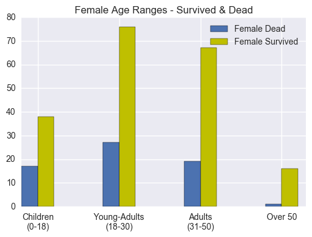

```python
dual_bar_plots(0, 1, 'Female')
```

There were more female survived in each age category.

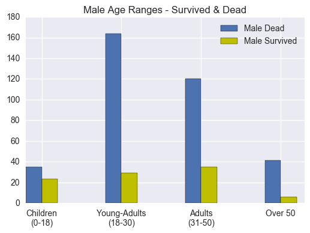

```python
dual_bar_plots(2, 3, 'Male')
```

There were more male dead in each age category.

Here is a swarm plot showing the overall age distribution for male and females.

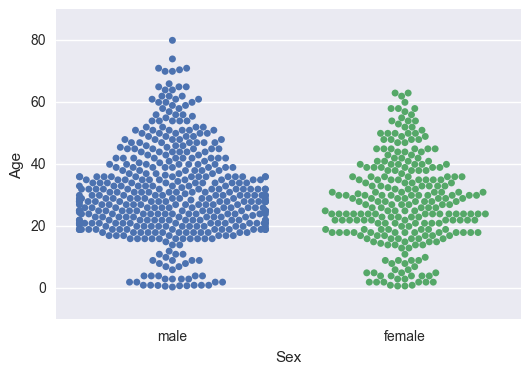

```python
sns.swarmplot(x='Sex', y='Age', data=df_new)
```

We see a large density of ages clustered in the 20-40 age range for both genders, but in the case of males there's a larger density of young adults and adults than in the female swarm plot.

### Survival and Age --> those under the age 18

I want to look into the claim that indeed children are the priority in terms of who gets to survive.

```python
#This apply method checks to see if the age values are less than 18, returns a true/false statement, and then sums up the true
#statements.

grouped_data_by_survival = df_new.groupby('Survived')
grouped_data_by_survival['Age'].apply(lambda x: (x<18).sum())
```

```
Survived
0    52
1    61
Name: Age, dtype: int64
```

```python
print("Out of reported ages, children made up a total of {}% of passengers".format((52+61)/float(len(df_new)) * 100))
```

```
Out of reported ages, children made up a total of 15.8263305322% of passengers
```

But how many of those children were in the upper class?

```python
grouped_by_survived_and_pclass = df_new.groupby(['Survived', 'Pclass'])
grouped_by_survived_and_pclass['Age'].apply(lambda x: (x<18).sum())
```

```
Survived  Pclass
0         1          1
          2          2
          3         49
1         1         11
          2         21
          3         29
Name: Age, dtype: int64
```

Total Children (under 18):  
Upper class - 12  
Middle class - 23  
Lower class - 78

```python
print("Percentage of Pclass1 children survived: {}%".format(11.0/12 * 100))
print("Percentage of Pclass2 children survived: {}%".format(21.0/23 * 100))
print("Percentage of Pclass3 children survived: {}%".format(29.0/78 * 100))
```

```
Percentage of Pclass1 children survived: 91.6666666667%
Percentage of Pclass2 children survived: 91.3043478261%
Percentage of Pclass3 children survived: 37.1794871795%
```

Almost all of the Pclass1 and Pclass2 children survived the Titanic. Only about 37.18% of Pclass3 children survived.

### Pclass, Survived, and Sex --> Those under age 18

```python
group_by_pclass_survival_sex = df_new.groupby(['Sex', 'Survived', 'Pclass'])
group_by_pclass_survival_sex['Age'].apply(lambda x: (x<18).sum())
```

```
Sex     Survived  Pclass
female  0         1          1
                  2          0
                  3         16
        1         1          7
                  2         12
                  3         19
male    0         1          0
                  2          2
                  3         33
        1         1          4
                  2          9
                  3         10
Name: Age, dtype: int64
```

Looks like the preference for pclass1 and pclass 2 were not only applied to females but also males, because lots of the lower class males who were children did not survive.

### Sex and SibSp

```python
grouped_by_sex_survived_pclass = df_new.groupby(['Sex','SibSp'])
print(grouped_by_sex_survived_pclass.mean()['Age'])

#What is this cell used for? Or for what purpose did you need to write the code for this cell? What use does it serve?
#It tells me the average age for the sex and sibsp. But is sibsp that important? I just thought perhaps I'll use this
#information for later.
```

```
Sex     SibSp
female  0        28.631944
        1        30.738889
        2        16.541667
        3        16.500000
        4         8.333333
        5        16.000000
male    0        32.615443
        1        29.461505
        2        28.230769
        3         8.750000
        4         6.416667
        5         8.750000
Name: Age, dtype: float64
```

Among the females, adults mostly clustered around 0 or 1 sibsp.  
Among the males, adults mostly clustered around 0, 1, or 2 sibsp.  
Well there's a reason why the ages are clustered the way they are. We already know that there were a lot of single men. Possibly the ship crewmen. They were workers on the ship. And we know that the average age for them was about 33 years old. In the 'Sex, SibSp, and Parch' subtopic, we find out that a total of 304 men had 0 parch and 0 sibsp.

### Sex and Parch

The goal is to see whether the amount of parch made a difference in those that survived and those that didn't. I'm assuming that those with a higher parch spent more time looking for their parch, and thus had less time to get to the life boats.

```python
grouped_by_sex_parch = df_new.groupby(['Sex', 'Parch'])
sex_parch_survived_sum = grouped_by_sex_parch.sum()['Survived']
print(sex_parch_survived_sum)
grouped_sex_parch_total = grouped_by_sex_parch['Survived'].count()
print(grouped_sex_parch_total)
```

```
Sex     Parch
female  0        120
        1         44
        2         29
        3          3
        4          0
        5          1
        6          0
male    0         66
        1         17
        2         10
        3          0
        4          0
        5          0
Name: Survived, dtype: int64
Sex     Parch
female  0        153
        1         55
        2         42
        3          4
        4          2
        5          4
        6          1
male    0        368
        1         55
        2         26
        3          1
        4          2
        5          1
Name: Survived, dtype: int64
```

```python
(sex_parch_survived_sum/grouped_sex_parch_total) * 100
```

```
Sex     Parch
female  0        78.431373
        1        80.000000
        2        69.047619
        3        75.000000
        4         0.000000
        5        25.000000
        6         0.000000
male    0        17.934783
        1        30.909091
        2        38.461538
        3         0.000000
        4         0.000000
        5         0.000000
Name: Survived, dtype: float64
```

Seems like the more parents/children that the female had, the less of a chance they had at survival. The opposite was true for males. The more parents or children they had, the more chance of a survival, but only up until parch 2.

But we want to look at the combination of sibsp/parch and how it affected survival.

Another thing to look at is, did all the males that had children or parents of the upper class, because from further analysis of the data lots of males who traveled alone were of the lower class. This can be figured out using the 'Sex, Sibsp, Parch, and Pclass' grouped data.

### Sex, SibSp, and Parch

```python
group_by_sex_sibsp_parch = df_new.groupby(['Sex', 'Parch', 'SibSp'])
sex_sibsp_parch_sum = group_by_sex_sibsp_parch.sum()['Survived']
print(group_by_sex_sibsp_parch.sum()['Survived'])
grouped_sex_sibsp_parch_total = group_by_sex_sibsp_parch['Survived'].count()
print(grouped_sex_sibsp_parch_total)
print(group_by_sex_sibsp_parch.mean()['Age'])
```

```
Sex     Parch  SibSp
female  0      0        79
               1        38
               2         1
               3         2
        1      0        20
               1        19
               2         5
               3         0
        2      0        15
               1         8
                        ..
male    1      3         0
               4         0
        2      0         5
```

[output cut: 54 more lines]

81.24% of men had 0 parch. 67.11% of men had 0 parch and 0 sibsp. This means there were a total of 304 men who traveled alone. Those 304 men were about 33 years old.

```python
print("Below is the percentages for parch/sibsp survived divided by parch/sibsp passengers total:")
(sex_sibsp_parch_sum/grouped_sex_sibsp_parch_total) * 100
```

```
Below is the percentages for parch/sibsp survived divided by parch/sibsp passengers total:
```

```
Sex     Parch  SibSp
female  0      0         79.000000
               1         77.551020
               2         50.000000
               3        100.000000
        1      0         86.956522
               1         76.000000
               2        100.000000
               3          0.000000
        2      0         88.235294
               1         80.000000
                           ...
male    1      3          0.000000
               4          0.000000
        2      0         55.555556
               1         57.142857
               3          0.000000
               4         33.333333
               5          0.000000
        3      1          0.000000
        4      1          0.000000
        5      1          0.000000
Name: Survived, dtype: float64
```

Previously we say a trend when we looked at the survival rates when we grouped the data by sex and parch. Now having combined sex, parch, and sibsp, we find that it's hard to find any noticeables trends. But one trend that I do see is that there seems to be more 0 percentages as the number of parch/sibsp increases. This could be because the more family a passenger had onboard with them, the harder it was to escape into the lifeboats.

### Sex, SibSp, Parch, and Pclass

I now want to look even further into how sibsp/parch interact with one's pclass.

```python
group_by_sex_sibsp_parch_pclass = df_new.groupby(['Sex', 'Parch', 'SibSp', 'Pclass'])
sex_sibsp_survived_pclass_sum = group_by_sex_sibsp_parch_pclass.sum()['Survived']
print(group_by_sex_sibsp_parch_pclass.sum()['Survived'])
grouped_sex_sibsp_parch_pclass_total = group_by_sex_sibsp_parch_pclass['Survived'].count()
print(grouped_sex_sibsp_parch_pclass_total)
#print(group_by_sex_sibsp_parch_pclass.mean())
```

```
Sex     Parch  SibSp  Pclass
female  0      0      1         31
                      2         27
                      3         21
               1      1         23
                      2         10
                      3          5
               2      1          1
                      3          0
               3      2          1
                      3          1
                                ..
male    2      1      2          0
                      3          1
               3      1          0
```

[output cut: 31 more lines]

Only 13.90% of lower class single males with 0 parch and 0 sibsp survived.  
There were 38 lower class females that rode alone.

```python
print("This is the percentages for parch/sibsp/pclass survivors divided by parch/sibsp/pclass passengers total:")
(sex_sibsp_survived_pclass_sum/grouped_sex_sibsp_parch_pclass_total) * 100
```

```
This is the percentages for parch/sibsp/pclass survivors divided by parch/sibsp/pclass passengers total:
```

```
Sex     Parch  SibSp  Pclass
female  0      0      1          96.875000
                      2          90.000000
                      3          55.263158
               1      1         100.000000
                      2          83.333333
                      3          35.714286
               2      1         100.000000
                      3           0.000000
               3      2         100.000000
                      3         100.000000
                                   ...
male    2      1      2           0.000000
                      3          50.000000
               3      1           0.000000
                      3           0.000000
               4      3          33.333333
               5      3           0.000000
        3      1      3           0.000000
        4      1      1           0.000000
                      3           0.000000
        5      1      3           0.000000
Name: Survived, dtype: float64
```

Previously I mentioned that many of the passengers among males and females are mostly clustered in the 0 parch category with ranging sibsp and pclass. Taking a look at the females, we see that pclass mattered in each parch/sibsp/pclass group. Despite the number of family members you had, the higher class you were the more of a chance of survival you had. The same went for males as well, although being a female in general meant that you had a higher chance of survival. If you look at the lower class females and the lower class males, the lower class females generally had a better chance of survival.

```python
group_by_sex_sibsp_parch_pclass.mean()['Age']

#This is data for everyone, I didn't qualify whether they died or survived.
```

```
Sex     Parch  SibSp  Pclass
female  0      0      1         34.937500
                      2         33.383333
                      3         23.565789
               1      1         37.434783
                      2         28.916667
                      3         25.035714
               2      1         53.000000
                      3         18.000000
               3      2         30.000000
                      3         33.000000
                                  ...
male    2      1      2         30.500000
                      3         13.500000
               3      1         19.000000
                      3          7.000000
               4      3          5.333333
               5      3          8.750000
        3      1      3         16.000000
        4      1      1         64.000000
                      3         40.000000
        5      1      3         39.000000
Name: Age, dtype: float64
```

The average age for upper class males who traveled alone was about 45 years old.  
The average age for middle class males who traveled alone was about 34 years old.  
The average age for lower class males who traveled alone was about 29 years old.

### Sex, Survived, Parch, SibSp, and Pclass

This is combining all the variables of interest together, and we're looking at age.

```python
group_by_sex_parch_sibsp_pclass_survived = df_new.groupby(['Sex', 'Survived', 'Parch', 'SibSp', 'Pclass'])
group_by_sex_parch_sibsp_pclass_survived.mean()['Age']
```

```
Sex     Survived  Parch  SibSp  Pclass
female  0         0      0      1         50.000000
                                2         39.666667
                                3         25.029412
                         1      2         35.500000
                                3         26.944444
                         2      3         18.000000
                  1      0      3         21.666667
                         1      2         26.000000
                                3         25.600000
                         3      3          5.500000
                                            ...
male    1         1      1      1         48.500000
                                2          2.916667
                                3          9.000000
                         2      2          1.000000
                  2      0      1         10.500000
                                2          0.915000
                                3          9.000000
                         1      1         15.973333
                                3          1.000000
                         4      3          3.000000
Name: Age, dtype: float64
```

### Survival and Age --> those above 50

```python
#We're wanting to find out the total number of elderly in the dataset.

over_50_count = df_new['Age'].apply(lambda x: (x>50))
```

```python
print("Total number of passengers above fifty: {}".format(over_50_count.sum()))
```

```
Total number of passengers above fifty: 64
```

```python
#We use the method apply to find the number of elderly for each group of sex/survived. The apply method takes an anon function,
#and sums up the true/false statements from the x>50 conditional statement.

grouped_data_by_sex_and_survived['Age'].apply(lambda x: (x>50).sum())
```

```
Sex     Survived
female  0            1
        1           16
male    0           41
        1            6
Name: Age, dtype: int64
```

```python
print("Percentage of females in those over age fifty: {}%".format(float(16)/over_50_count.sum() * 100))
print("Percentage of males in those over age fifty: {}%".format(float(47)/over_50_count.sum() * 100))

print('\n')

print("Percentage of female survivors over fifty: {}%".format(15.0/17 * 100))
print("Percentage of male survivors over fifty: {}%".format(6.0/47 * 100))
```

[output not shown]

Almost all of the the females over 50 survived. Only 12.77% of those males over 50 survived. Maybe they cared more about taking the elderly females over the elderly males.

### Sex, Survived, Pclass --> those above 50

```python
group_by_survived_pclass = df_new.groupby(['Sex', 'Survived', 'Pclass'])
group_by_survived_pclass['Age'].apply(lambda x: (x>50).sum())
```

```
Sex     Survived  Pclass
female  0         1          0
                  2          1
                  3          0
        1         1         13
                  2          2
                  3          1
male    0         1         21
                  2         11
                  3          9
        1         1          5
                  2          1
                  3          0
Name: Age, dtype: int64
```

Most of the elderly folk were part of the upper class.

### Pclass and Survival

```python
grouped_by_pclass = df_new.groupby('Pclass')
```

```python
grouped_by_pclass.sum()
```

| Pclass | PassengerId | Survived | Age | SibSp | Parch | Fare |
| --- | --- | --- | --- | --- | --- | --- |
| 1 | 86297 | 122 | 7111.42 | 84 | 76 | 16360.8543 |
| 2 | 77358 | 83 | 5168.83 | 74 | 70 | 3714.5792 |
| 3 | 156633 | 85 | 8924.92 | 208 | 162 | 4696.4495 |

```python
#How many of each pclass were there?

pclass_value_count = df_new['Pclass'].value_counts()

print("Total number of Pclass-1: {}".format(pclass_value_count.iloc[1]))
print("Total number of Pclass-2: {}".format(pclass_value_count.iloc[2]))
print("Total number of Pclass-3: {}".format(pclass_value_count.iloc[0]))
```

```
Total number of Pclass-1: 186
Total number of Pclass-2: 173
Total number of Pclass-3: 355
```

```python
print("Percentage of Pclass1 survived: {}%".format(float(120)/pclass_value_count.iloc[1] * 100))
print("Percentage of Pclass2 survived: {}%".format(float(83)/pclass_value_count.iloc[2] * 100))
print("Percentage of Pclass3 survived: {}%".format(float(85)/pclass_value_count.iloc[0] * 100))
```

[output not shown]

The upper class had the most percentage of survivors, then followed the middle class and lower class passengers. One possible reason for this could have been that the upper class passengers were all housed in the upper levels of the Titanic, which led to more survivors because it was easier to get outside. Another possibility is that the upper class were taken care of first, and then those with lower socio-economic status were taken care of last.

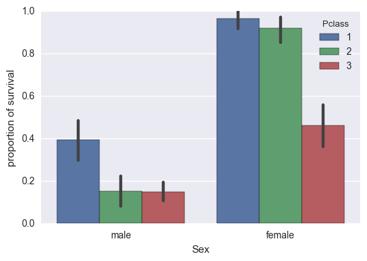

```python
sns.barplot(data=df_new, x="Sex", hue='Pclass', y='Survived', estimator=np.mean);
plt.ylabel('proportion of survival');
```

*Disclaimer --> this barplot code above was given to me as a suggestion from a reviewer from Udacity.

This bar plot above shows the proportion of survived for each sex and pclass grouping. What's interesting to note here is that the male pclass1 has a similar confidence interval to the female pclass3. This indicates that the difference between the rates is not statistically significant.

### Pclass, Sex, and Survival

```python
grouped_by_pclass_sex = df_new.groupby(['Sex', 'Pclass'])
print(grouped_by_pclass_sex.sum()['Survived'])
print(grouped_by_pclass_sex['Survived'].count())
print(grouped_by_pclass_sex.sum()['Survived']/grouped_by_pclass_sex['Survived'].count() * 100)
```

```
Sex     Pclass
female  1         82
        2         68
        3         47
male    1         40
        2         15
        3         38
Name: Survived, dtype: int64
Sex     Pclass
female  1          85
        2          74
        3         102
male    1         101
        2          99
        3         253
Name: Survived, dtype: int64
Sex     Pclass
female  1         96.470588
        2         91.891892
        3         46.078431
male    1         39.603960
        2         15.151515
        3         15.019763
Name: Survived, dtype: float64
```

[figure not shown]

```python
plt.pie([70.67, 29.33], labels=['Males in lower class', 'Females in lower class'], shadow=True, autopct='%1.1f%%',
        explode=[0, 0.1], colors=['yellow', 'white'])
plt.axis('equal')
plt.title('M/F Percentage among Lower Class', y=1.08)
```

[figure not shown]

```python
plt.pie([347, 108, 122], labels=['Male - lower class', 'Male - middle class', 'Male - upper class'], shadow=True,
        autopct='%1.1f%%', explode=[0, 0, 0.1], colors=['yellow', 'white', 'pink'])
plt.axis('equal')
plt.title('Male percentages among classes', y=1.08)
```

[figure not shown]

```python
plt.pie([144, 76, 94], labels=['Female - lower class', 'Female - middle class', 'Female - upper class'], shadow=True,
        autopct='%1.1f%%', explode=[0, 0, 0.1], colors=['yellow', 'white', 'pink'])
plt.axis('equal')
plt.title('Female percentages among classes', y=1.08)
```

## Limitations

There were lots of missing data in the age and cabin column. Since I was not using the cabin column for my analysis I took it out from the dataset. There were 177 missing values in the age column, and so I created a new dataset that took out all the rows with missing age values. Upon further exploration I found that there were two missing values in the 'Embarked' column. This was a problem because when I called the dataframe method 'dropna' I was removing an additional two rows I didn't have to because of the two values missing in the 'Embarked' column. The new dataset also took this into account and removed this problematic column.

## Conclusion

The below analysis are but describing tendencies and are in no way definitive predictions. The conclusions that I come up with are but speculations that are backed up by the data, though loosely. I understand that this dataset is but a sample, and as I was analyzing it I made the assumption that this sample is representative of the titanic population.

There were four major indicators that predicted one's survival: female gender, pclass, child, and elderly.

Almost all of the the females over 50 survived. Only 12.7% of those males over 50 survived. Maybe they cared more about taking the elderly females over the elderly males.

The female elderly were taken great care for, while the male elderly not so much. Only about 13% of them survived. Specifically out of 47 elderly male, only 6 of them survived. Whereas out of the 17 female elderly, only 16 of them survived. Perhaps since there were so few elderly female that they were easier to locate than the elderly male. And amidst all the choas the elderly male were forgotten because they were too hard to locate. Another interesting thing is that the majority of the elderly folk were in the upper classes. 26 elderly male in the upper class, and 13 elderly female in the upper class. That makes about roughly 60.94% of the elderly population who were in the upper class.